# Spotify R report

Author

Lidia Carvalho

# Let’s talk about Linkin Park

## Who is Linkin Park?

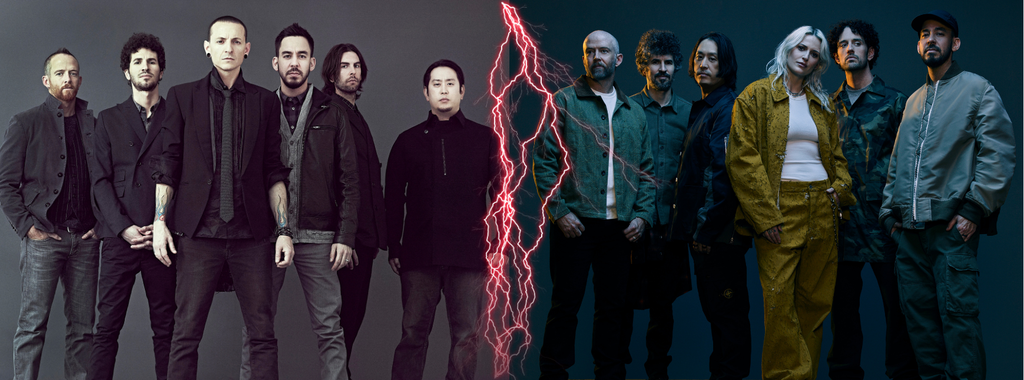

Linkin Park is an American rock, alternative metal and grunge band formed in 1996 and which rose to international fame with their first album, *Hybrid Theory*, in 2000.

They entered a hiatus in 2017 after the main vocalist, Chester Bennington, committed suicide during the releasing of their album *One More Light*.

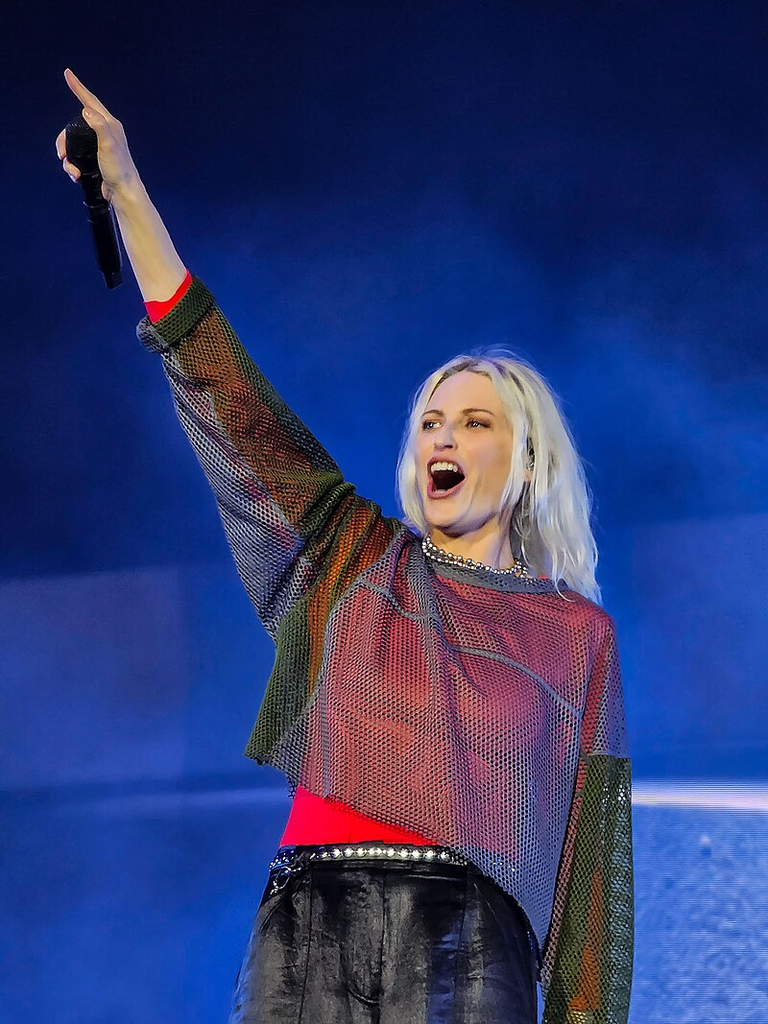

In September 2023 the band made their official comeback with new vocalist Emily Armstrong and with drummer Colin Brittain replacing Rob Bourdon, from the original lineup. Then, in late 2024, they released the new album *From Zero.* It will not be included in this analysis as the dataset is from 2022.

```r
# These are packages I used for the analysis
library("ggplot2")
library("dplyr")
library("ggrepel")
library("Hmisc")
library("forcats")
# This is how i loaded the dataset after excel pre-processing
LinkinPark <- read.csv(file = "C://Users//carva//Downloads//Data science data//Spotify project Lidia//Linkin park csv.csv",
         header = TRUE, sep = ";", dec=",")
LinkinPark <- LinkinPark[,-23:-16384]
```

## Data pre-processing

The data on Linkin Park tracks was filtered from a 2022 downloaded dataset from the Spotify API. I noticed that in this dataset, nearly every track was duplicated or even tripled, with the only difference between the records being the “genre” variable. For instance, “BURN IT DOWN” from *LIVING THINGS* was represented three times in the dataset, as it is recorded as alternative, grunge and metal respectively. I removed the duplicate tracks and added two new variables to record secondary and tertiary genres.

After importing to R, I realized that Linkin Park had too many albums to make reasonable graphs. Therefore, I chose to filter out albums with less than 3 songs.The albums *Meteora* and *Hybrid Theory* were present in both the orginal version and a BonusEdition. As the Bonus editions consistently outperformed the original record in terms of popularity, I decided to include them in the analysis instead. I ended up with 8 albums listed below. I also added a variable with the release year of each album.

```r
LinkinPark_reduced <- subset(LinkinPark, album_name %in% c("A Thousand Suns","Hybrid Theory (Bonus Edition)", "LIVING THINGS","Meteora (Bonus Edition)","Minutes to Midnight", "One More Light", "Reanimation","The Hunting Party"))


LinkinPark_reduced <- LinkinPark_reduced %>% mutate(album_release_year = case_when(
  album_name == "A Thousand Suns" ~ 2010,
  album_name == "Hybrid Theory (Bonus Edition)" ~ 2000,
  album_name == "LIVING THINGS" ~ 2012,
  album_name == "Meteora (Bonus Edition)" ~ 2003,
  album_name == "Minutes to Midnight" ~ 2007,
  album_name == "One More Light" ~ 2017,
  album_name == "Reanimation" ~ 2002,
  album_name == "The Hunting Party" ~ 2014,
  TRUE ~ 0
))
```

## Data Analysis

### Popularity and energy per album

I wanted to visualize Linkin Park’s popularity across its career, knowing it was skyrocketed to fame in the 2000s with it’s first album. Therefore I made boxplots of each album, ordered by release year.

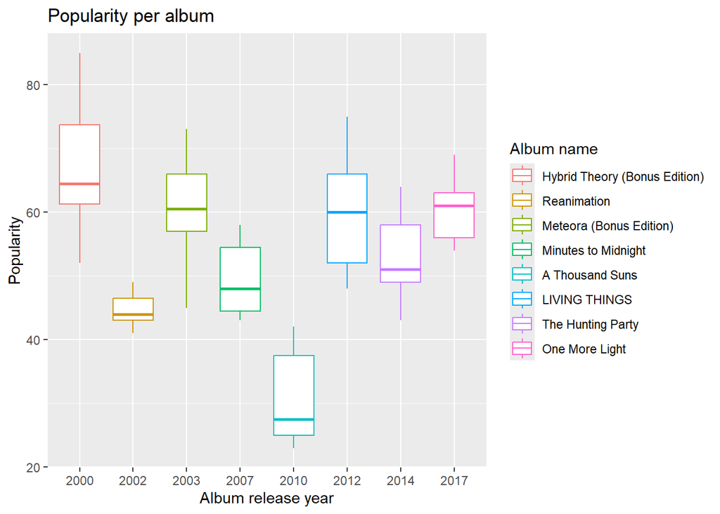

```r
LinkinPark_reduced %>%
  mutate(album_name = fct_reorder(album_name, as.numeric(album_release_year))) %>%
  ggplot(aes(x=as.factor(album_release_year), y=popularity, color=album_name)) +
  geom_boxplot() +
  labs(title="Popularity per album", x="Album release year", y="Popularity", colour="Album name")
```

Although their very first album, *Hybrid Theory* (which includes the mega hits “In the End”, “Papercut”, “Crawling” and “One Step Closer”), was by far in 2022 the most popular, they kept a consistent output of popular albums. All the way to 2017, where their album *One More Light* was very well received. With a clear outlier, however: *A Thousand Suns*, from 2010. What happened? Why did this album not resonate with fans?

The first thing that came to mind: “energy”. A staple of the metal genre, perhaps it was lacking the songs of *A Thousand Suns*. However, analyzing the histogram of energy per album, it does not seem that is the case. Actually, the album that broke with the high-energy trend was the last one *One More Light*, which introduced more “pop” elements. Just to be sure, I executed a linear regression between energy and popularity for every track, which returned no clear positive correlation.

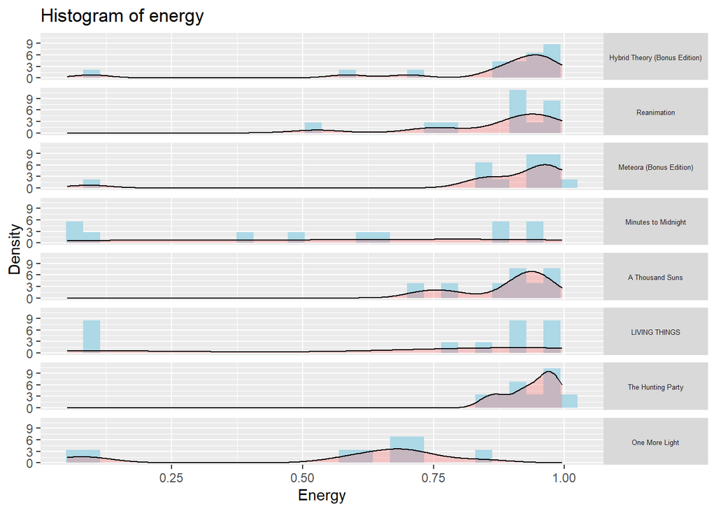

```r
## Histogram of energy
LinkinPark_reduced %>%
  mutate(album_name = fct_reorder(album_name, as.numeric(album_release_year))) %>%
  ggplot( aes(x=energy))+
  geom_histogram(aes(y=..density..), fill="lightblue")+
  geom_density(fill="#FF6666", alpha = 0.3) +
  facet_grid(album_name ~ .)+
  labs(title="Histogram of energy", x="Energy", y="Density") +
  theme(strip.text.y = element_text(size = 5, angle=0))
```

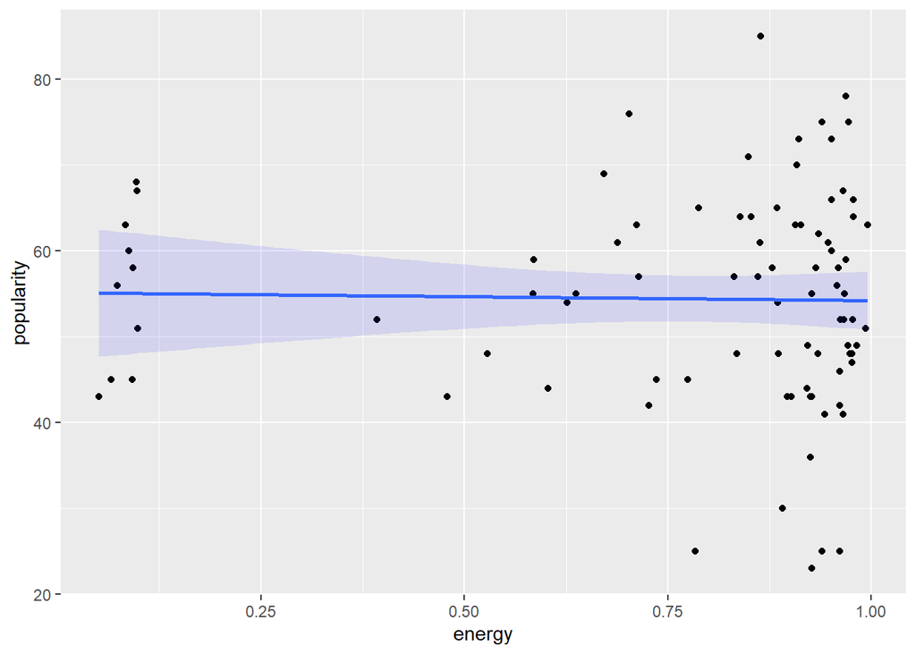

```r
## Linear regression of energy and popularity
ggplot(LinkinPark_reduced, aes(x = energy, y = popularity))+
  geom_point()+
  geom_smooth(method= "lm", alpha = 0.1, fill="blue")
```

I tested several other variables, however I could not find any variation in the recorded variables that could explain *A Thousand Suns’* lack of sucess. Perhaps it is a phenomenon that Spotify’s variables can’t capture.

## Scatterplots

Something else I observed is that, in fact, Linkin Park’s discography does contain mostly high-energy tracks, but also an interesting number of very low-energy songs. I wondered if other variables had a similar distribution.

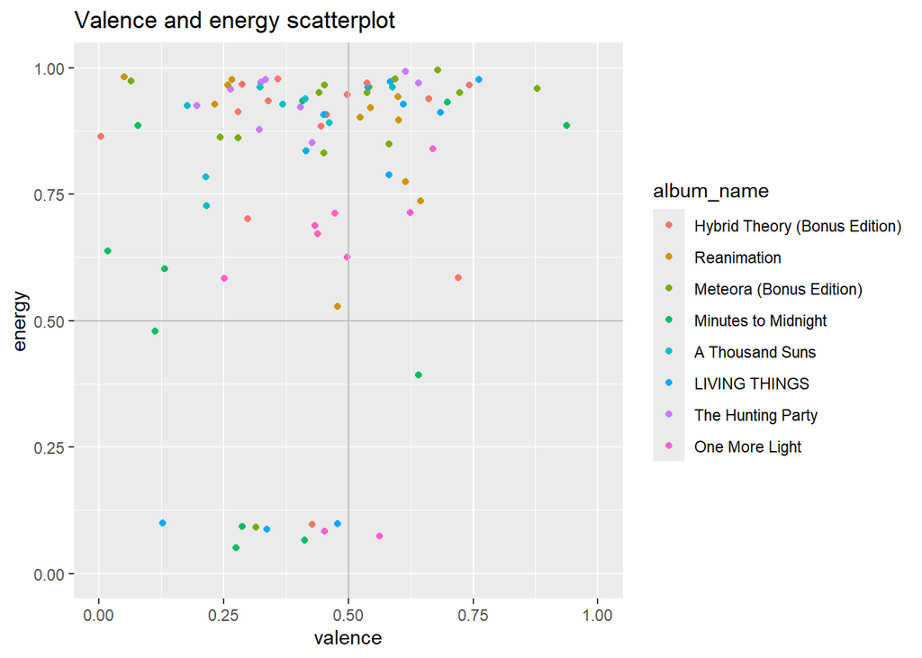

```r
#Plotting energy and valence with no labels

LinkinPark_reduced %>%
  mutate(album_name = fct_reorder(album_name, as.numeric(album_release_year))) %>%
  ggplot(aes(x = valence, y = energy, color = album_name))+
  geom_point()+
  geom_hline(yintercept = 0.5, color="grey")+
  geom_vline(xintercept = 0.5, color="grey") +
  xlim(0, 1)+ ylim(0,1)+
  labs(title="Valence and energy scatterplot")
```

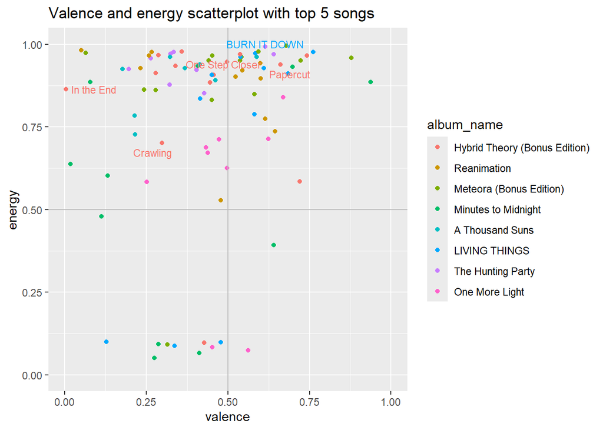

```r
## Valence and energy plotting with labels

topSongs <- slice_max(LinkinPark_reduced, LinkinPark_reduced$popularity, n=5)
bottomSongs <- slice_min(LinkinPark_reduced, LinkinPark_reduced$popularity, n=5)

LinkinPark_reduced %>%
  mutate(album_name = fct_reorder(album_name, as.numeric(album_release_year))) %>%
  ggplot(aes(x = valence, y = energy, color = album_name))+
  geom_point()+
  geom_hline(yintercept = 0.5, color="grey")+
  geom_vline(xintercept = 0.5, color="grey") +
  xlim(0, 1)+ ylim(0,1)+
  labs(title="Valence and energy scatterplot with top 5 songs") +
  geom_text_repel(data=topSongs, aes(label=track_name),size = 3, show.legend = FALSE)
```

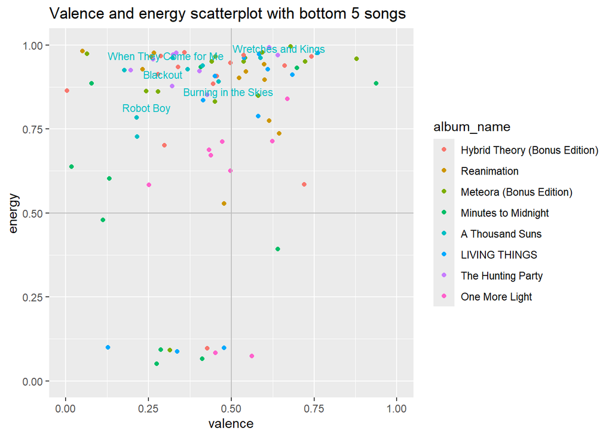

```r
LinkinPark_reduced %>%
  mutate(album_name = fct_reorder(album_name, as.numeric(album_release_year))) %>%
  ggplot(aes(x = valence, y = energy, color = album_name))+
  geom_point()+
  geom_hline(yintercept = 0.5, color="grey")+
  geom_vline(xintercept = 0.5, color="grey") +
  xlim(0, 1)+ ylim(0,1)+
  labs(title="Valence and energy scatterplot with bottom 5 songs") +
  geom_text_repel(data=bottomSongs, aes(label=track_name),size = 3, show.legend = FALSE)
```

Again, the distribution of energy is very interesting, with very extreme values. The distribution of valence, or “positiveness”, is also wide, which is surprising for a band who’s lyrics are not positive at all. Most of their songs reference depression, suicidal ideation, and other mental health struggles.

Regarding popularity, their top 5 most popular songs are mostly on the “high-energy” end of the spectrum, but so are their bottom 5 least popular songs.

A good amount of Linkin Park tracks, including the very popular “Papercut” lay on the right hand upper quadrant, called the “happy” quadrant. However, I don’t believe any fan of Papercut, or of the band in general, would ever call the emotion it evokes “happiness”, as it is a song about paranoia and anxiety. Perhaps that is the genius of Linkin Park: break musical expectations and use musical “irony”.

Similarly, although the metal genre is known for its very loud tracks and long instrumental solos, Linkin Park breaks this “rule” by offering a variety of loudness and speechiness in their tracks.

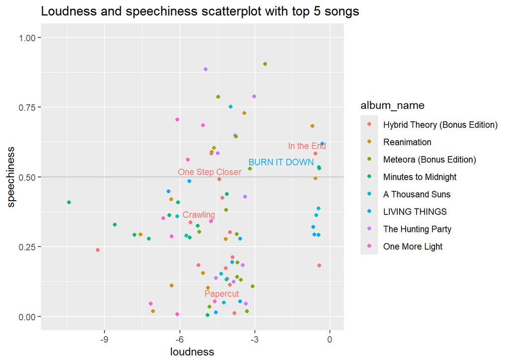

```r
LinkinPark_reduced %>%
  mutate(album_name = fct_reorder(album_name, as.numeric(album_release_year))) %>%
  ggplot(aes(x = loudness, y = speechiness, color = album_name))+
  geom_point()+
  geom_hline(yintercept = 0.5, color="grey")+
  geom_vline(xintercept = 0.5, color="grey") +
  xlim(-11, 0)+ ylim(0,1)+
  labs(title="Loudness and speechiness scatterplot with top 5 songs") +
  geom_text_repel(data=topSongs, aes(label=track_name),size = 3, show.legend = FALSE)
```

## Song snippets

To represent this variety of track styles within Linkin Park’s discography, I chose two snippets of songs that are polar opposites on nearly every variable.

“BURN IT DOWN” from *LIVING THINGS* (2012)

Valence: 0.585

Energy: 0.972

Loudness: -0.445

Speechiness: 0.534

[video not shown]

“What I’ve Done” from *Minutes to Midnight*

Valence: 0.287

Energy: 0.093

Loudness: -5.285

Speechiness: 0.324

[video not shown]

With these snippets, we can (hopefully) see that Linkin Park still has their very distinct sound and style even across songs that are, on paper, entirely different.